# Modelling

Brian Bombasi

3/31/2023

# 1 The Business Problem

Swire Coca-Cola wants to predict the profitability and success of new local B2B restaurants and the profitability and risk factor of current customers(quick service, restaurants, retails and etc) to make informed decisions on pricing and funding. Our team will use historical data and machine learning techniques to build a predictive model that identifies profitable restaurant types and how long it takes for both new and old customers to become profitable.

The project will provide Swire Coca-Cola with insight on their current market, demands for each product and different customer segments.Our team also hope to provide Swire Coca-Cola with findings regarding customer profitability and what factors contribute towards a customer’s success and which reasons create risk for Swire.

# 2 Analytical Problems and Objective

To create a predictive model that would highlight key indicators of success for Swire’s customers(b2b businesses and etc). This would help Swire identify and target potentially successful businesses and create a long lasting partnership. We hope that this would also identify key aspects of a risky businesses.

We also want to deliver a model that would predict profitability (PROFITABLE) or TOTAL_PROFIT (target variable) based on discounts given and various other variables. By doing so we hope to show how different variables can affect a customers(both successful and risky ventures) business profitability in the long run.

In this project I focused on TOTAL_PROFITS and a binary variable called PROFITABLE. Since most of swire’s customers become profitable over a period of time, I made sure to balance profitable and non profitable customers by using the median as the separator for profitable and non profitable. Anything below the median of the total profit will be considered non profitable. I switched between PROFITABLE and TOTAL_PROFIT as the main target variable to see which variables affect a customer’s profitability. I ran an xgboost model, Linear Regression, Random Forest and a multiple regression analysis to see how TOTAL_PROFIT or PROFITABLE is affected.

# 3 Data Preparation

The data is created by our team, it comprises of Sales and Customer Data. We took the excel sheets and uploaded them into a database where we were able to join the two files based on CUSTOMER_NUMBER_BLINDED. We also created new columns like ACTIVE which identifies if a customer has been actively purchasing products in the last 3 months. We made the assumption that 3 months is the threshold whether a customer can be considered active or not active.

years_diff is the max posting date - the min posting date. Longevity is the max posting date - on boarding date CLVT stands for customer life time value

As shown below I have create the PROFITABLE column which identifies a customer as profitable if they are above the median of total_profit

I have dropped several columns as they were not needed for the Analysis.

Any rows containing NAs were dropped

```r
df_team <- read.csv(file = "customer_features.csv", stringsAsFactors = TRUE)
df1 <- read.csv(file = "Customer.csv" , stringsAsFactors = TRUE)
merged <- merge(df1, df_team, by="CUSTOMER_NUMBER_BLINDED")

#Profitable logic
# A profitable business is considered profitable if its above the mean.
mean(merged$TOTAL_PROFIT)
```

```
## [1] 7014.707
```

```r
median(merged$TOTAL_PROFIT)
```

```
## [1] 1945.76
```

```r
merged$PROFITABLE <- ifelse(merged$TOTAL_PROFIT > 1945.76, 1, 0)
merged$PROFITABLE <- as.factor(merged$PROFITABLE)

df <- subset(merged, select = c("UNIQUE_PRODUCTS", "EXPECTED_TRANS_YEAR", "years_diff", "TMRR_MAX", "longetivity", "PROFITABLE"))
df2 <- subset(merged, select = c("ACTIVE", "UNIQUE_PRODUCTS", "EXPECTED_TRANS_YEAR", "years_diff", "TMRR_MAX", "longetivity", "PROFITABLE"))

# Check for missing values
sum(is.na(df)) # check the count of missing values
```

```
## [1] 0
```

```r
getwd()
```

```
## [1] "C:/Users/bomba/Desktop/Do not delete"
```

```r
# Remove missing values
df <- df %>% drop_na()
str(df)
```

```
## 'data.frame':    34997 obs. of  6 variables:
##  $ UNIQUE_PRODUCTS    : int  4 32 12 38 9 2 12 11 78 16 ...
##  $ EXPECTED_TRANS_YEAR: num  30.4 351.7 26.9 328.7 33.1 ...
##  $ years_diff         : num  1.48 1.93 1.97 2.01 1.69 ...
##  $ TMRR_MAX           : num  1.77 9.41 3.9 52.12 7.06 ...
##  $ longetivity        : num  6.31 9.68 2.61 9.84 13.16 ...
##  $ PROFITABLE         : Factor w/ 2 levels "0","1": 1 2 1 2 1 1 2 1 2 2 ...
```

# 4 Data Exploration:

I wanted to showcase how balanced profitable is.

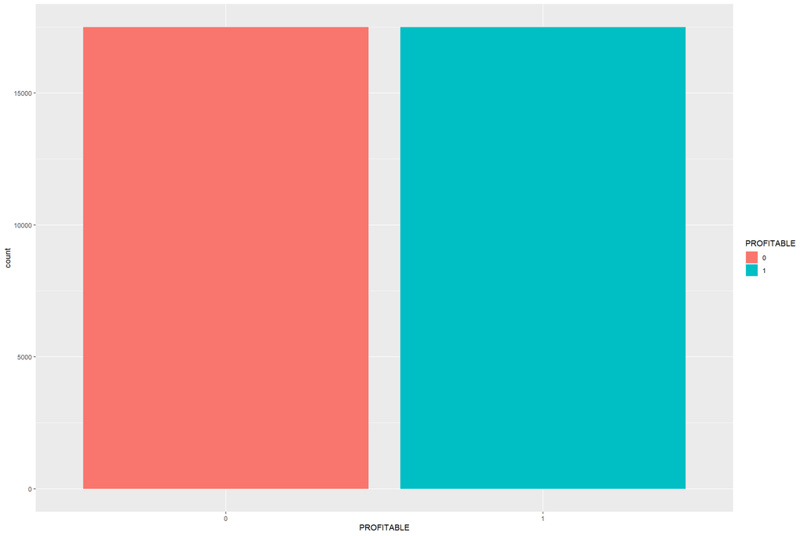

```r
# Create a bar plot of profitable customers
ggplot(df, aes(x=PROFITABLE, fill=PROFITABLE)) +
  geom_bar()
```

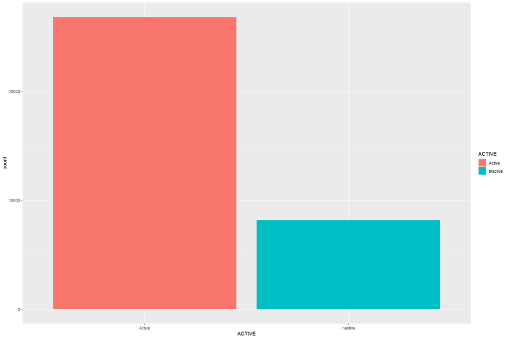

```r
# Create a bar plot of active customers
ggplot(df2, aes(x=ACTIVE, fill=ACTIVE)) +
  geom_bar()
```

# 5 Candidate models

List the models you considered: I considered various models for my analysis, including regression models such as linear and multiple regression to investigate the relationship between my target variables TOTAL_PROFIT and PROFITABLE and the various dependent variables. However, since my dataset also contained categorical data, I also explored classification models to predict whether a customer will become a profitable customer to Swire.

One model I used was the Random Forest Model due to its ability to perform both classification and regression tasks, and its features for outlier detection and feature selection. I also opted to use xgboost due to its ability to handle high dimensional data and built and trained a regression model using this algorithm. Finally, I evaluated the performance of both models on a test set for both target variables.